# simpimp_0pros-stat

These are stats for simpimp CogSci 2015.

Read file:

```r
rm(list = ls())
source("../analysis/helpers/useful.R")
source("../analysis/helpers/et_helper.R")
detach(package:plyr)
library(dplyr)
# read data
d <- read.csv("../data/simpimp_0pros-short.csv")
```

# Experiment 1

## lmer: effect of trial type and age on accuracy in Expt 1 (Table 1)

### Set up aggregate

```r
mss <- d %>%
  filter(t.crit >= 1 & t.crit <= 4) %>%
  filter(age_group != "adult") %>%
  filter(expt == "1") %>%
  group_by(trial_type, age_group, subid, item) %>%
  summarise(correct = mean(correct, na.rm = TRUE))

mss$subid <- factor(mss$subid)
mss$age_group <- as.numeric(as.character(mss$age_group)) # age as continuous
mss$trial_type <- relevel(mss$trial_type, "cs")
```

### plot

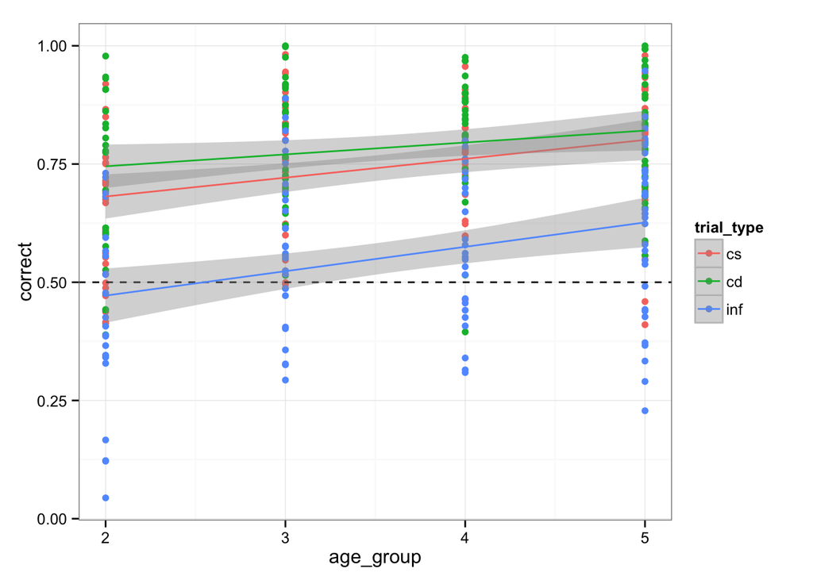

```r
# plot
ms <- mss %>%
  group_by(trial_type, age_group, subid) %>%
  summarise(correct = mean(correct, na.rm = TRUE))

qplot(age_group, correct, col=trial_type, data=ms) +
  geom_hline(yintercept=.5,lty=2) +
  geom_smooth(method="lm")
```

### model

```r
# lmer
simp.lm <- lmer(correct ~ age_group * trial_type
                + (trial_type | subid) + (age_group | item), # (age_group + trial_type | item) fails to converge
                data=mss)
summary(simp.lm)
```

```
## Linear mixed model fit by REML ['lmerMod']
## Formula:
## correct ~ age_group * trial_type + (trial_type | subid) + (age_group |
##     item)
##    Data: mss
##
## REML criterion at convergence: 190.6
##
## Scaled residuals:
##    Min     1Q Median     3Q    Max
## -3.490 -0.576  0.197  0.690  2.479
##
## Random effects:
##  Groups   Name          Variance Std.Dev. Corr
##  subid    (Intercept)   0.011388 0.1067
##           trial_typecd  0.004333 0.0658   -0.78
##           trial_typeinf 0.012035 0.1097   -0.53  0.94
##  item     (Intercept)   0.002920 0.0540
##           age_group     0.000115 0.0107   -1.00
##  Residual               0.058312 0.2415
## Number of obs: 1539, groups:  subid, 109; item, 12
##
## Fixed effects:
##                         Estimate Std. Error t value
## (Intercept)               0.5994     0.0487   12.30
## age_group                 0.0403     0.0124    3.24
## trial_typecd              0.1035     0.0573    1.81
## trial_typeinf            -0.2389     0.0648   -3.69
## age_group:trial_typecd   -0.0170     0.0148   -1.15
## age_group:trial_typeinf   0.0145     0.0168    0.86
##
## Correlation of Fixed Effects:
##                 (Intr) ag_grp trl_typc trl_typn ag_grp:trl_typc
## age_group       -0.956
## trial_typcd     -0.557  0.539
## trial_typnf     -0.522  0.505  0.482
## ag_grp:trl_typc  0.532 -0.563 -0.956   -0.457
## ag_grp:trl_typn  0.497 -0.525 -0.455   -0.956    0.472
```

Looks like we have main effects of age and trial type, but no interaction. Thus, across all trial types, there is a developmental trend of improved performance.

What if we look only at inf trials?

## lmer: effect of age on accuracy within inference trials in Expt 1 (For table 2)

### set up aggregate

```r
# looking at just inf trials
# window: 1-4 seconds
mss <- d %>%
  filter(t.crit >= 1 & t.crit <= 4) %>%
  filter(age_group != "adult") %>%
  filter(expt == "1") %>%
  filter(trial_type == "inf") %>%
  group_by(trial_type, age_group, subid, item) %>%
  summarise(correct = mean(correct, na.rm = TRUE))

mss$subid <- factor(mss$subid)
mss$age_group <- as.numeric(as.character(mss$age_group)) # age as continuous
mss$trial_type <- relevel(mss$trial_type, "cs")
```

### model

```r
simp.lm <- lmer(correct ~ age_group +
                + (1 | subid) + (age_group | item),
                data=mss) # more complex random effects fail to converge
summary(simp.lm)
```

```
## Linear mixed model fit by REML ['lmerMod']
## Formula: correct ~ age_group + +(1 | subid) + (age_group | item)
##    Data: mss
##
## REML criterion at convergence: 132.1
##
## Scaled residuals:
##     Min      1Q  Median      3Q     Max
## -2.3537 -0.7096  0.0119  0.7131  2.0277
##
## Random effects:
##  Groups   Name        Variance Std.Dev. Corr
##  subid    (Intercept) 5.36e-03 7.32e-02
##  item     (Intercept) 2.38e-12 1.54e-06
##           age_group   1.27e-13 3.56e-07 -1.00
##  Residual             7.58e-02 2.75e-01
## Number of obs: 377, groups:  subid, 109; item, 8
##
## Fixed effects:
##             Estimate Std. Error t value
## (Intercept)   0.3574     0.0538    6.65
## age_group     0.0561     0.0142    3.96
##
## Correlation of Fixed Effects:
##           (Intr)
## age_group -0.955
```

We see significant main effect of age within inf trials, such that with increasing age, children’s looking at the inferential target (a measure of their implicature computation) increases.

# Experiment 2

## lmer: effect of trial type, age, and window on accuracy in Expt 2 (Table 3)

```r
##Experiment 2: prosody
#aggregate data across subjects and items
mss <- d %>%
  filter(age_group == "3" | age_group == "4") %>%
  filter(expt == "2") %>%
  filter(t.crit > 1 & t.crit <= 4.2) %>%
  mutate(window = ifelse(t.crit > 1 & t.crit <= 2.6, "early", "late")) %>%
  group_by(trial_type, age_group, window, subid, item) %>%
  summarise(correct = mean(correct, na.rm = TRUE))

mss$subid <- factor(mss$subid)
mss$age_group <- as.factor(mss$age_group) # age as continuous
mss$trial_type <- relevel(mss$trial_type, "cs")
```

### plot

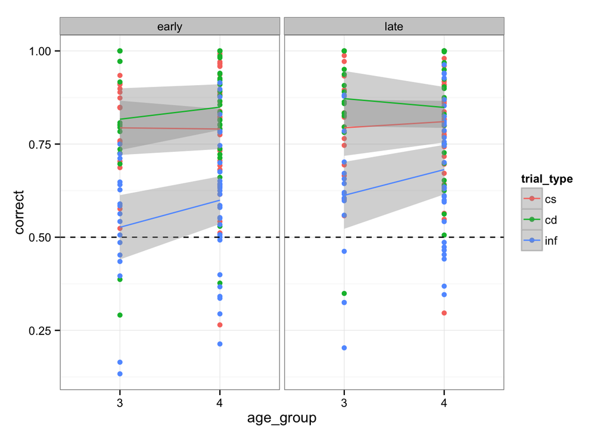

```r
ms <- mss %>%
  group_by(trial_type, age_group, window, subid) %>%
  summarise(correct = mean(correct, na.rm = TRUE))

qplot(age_group, correct, col=trial_type, data=ms) +
  facet_wrap(~window) +
  geom_hline(yintercept=.5,lty=2) +
  geom_smooth(method="lm", aes(group=trial_type))
```

### model

```r
simp.lm <- lmer(correct ~ age_group * trial_type * window
                + (trial_type + window | subid) + (age_group + window | item),
                data=mss)
summary(simp.lm)
```

```
## Linear mixed model fit by REML ['lmerMod']
## Formula:
## correct ~ age_group * trial_type * window + (trial_type + window |
##     subid) + (age_group + window | item)
##    Data: mss
##
## REML criterion at convergence: 463.8
##
## Scaled residuals:
##    Min     1Q Median     3Q    Max
## -3.364 -0.480  0.331  0.622  1.982
##
## Random effects:
##  Groups   Name          Variance Std.Dev. Corr
##  subid    (Intercept)   0.014016 0.1184
##           trial_typecd  0.004507 0.0671   -0.74
##           trial_typeinf 0.014500 0.1204   -0.66  0.65
##           windowlate    0.001296 0.0360   -0.06 -0.63 -0.24
##  item     (Intercept)   0.000298 0.0173
##           age_group4    0.000310 0.0176   -1.00
##           windowlate    0.000430 0.0207   -1.00  1.00
##  Residual               0.072754 0.2697
## Number of obs: 1404, groups:  subid, 48; item, 12
##
## Fixed effects:
##                                     Estimate Std. Error t value
## (Intercept)                          0.79969    0.03800   21.04
## age_group4                          -0.00892    0.04698   -0.19
## trial_typecd                         0.02699    0.04575    0.59
## trial_typeinf                       -0.26231    0.05172   -5.07
## windowlate                          -0.01672    0.03645   -0.46
## age_group4:trial_typecd              0.03662    0.05637    0.65
## age_group4:trial_typeinf             0.06849    0.06400    1.07
## age_group4:windowlate                0.03186    0.04428    0.72
## trial_typecd:windowlate              0.05009    0.06093    0.82
## trial_typeinf:windowlate             0.10440    0.06044    1.73
## age_group4:trial_typecd:windowlate  -0.06918    0.07457   -0.93
## age_group4:trial_typeinf:windowlate -0.03768    0.07431   -0.51
##
## Correlation of Fixed Effects:
```

[output cut: 21 more lines]

```
## trl_typnf:w        0.468            0.450  0.336
## ag_grp4:trl_typc: -0.187           -0.557 -0.809    -0.268
## ag_grp4:trl_typn: -0.573           -0.560 -0.266    -0.804
##                   ag_grp4:trl_typc:
## age_group4
## trial_typcd
## trial_typnf
## windowlate
## ag_grp4:trl_typc
## ag_grp4:trl_typn
## ag_grp4:wnd
## trl_typcd:w
## trl_typnf:w
## ag_grp4:trl_typc:
## ag_grp4:trl_typn:  0.332
```

```r
anova(simp.lm)
```

```
## Analysis of Variance Table
##                             Df Sum Sq Mean Sq F value
## age_group                    1   0.05    0.05    0.66
## trial_type                   2   6.63    3.31   45.55
## window                       1   0.17    0.17    2.35
## age_group:trial_type         2   0.07    0.04    0.51
## age_group:window             1   0.00    0.00    0.02
## trial_type:window            2   0.39    0.20    2.70
## age_group:trial_type:window  2   0.07    0.03    0.45
```

Within Exp 2: - main effect of trial type (inference) - NO significant interaction between inference x late window

What if we look at two experiments together, only at inference trials? We expect to see interaction between expt x window such that children had greater accuracy rate in inference trials in Exp 2 in the late window.

## lmer: effect of age and window in inf trials in Expt 1 and 2 (Table 4)

```r
mss <- d %>%
  filter(age_group == "3" | age_group == "4") %>%
  filter((expt == "1" & t.crit > .78 & t.crit <= 3.62) |
           (expt == "2" & t.crit > 1.16 & t.crit <= 4)) %>%
  filter(trial_type == "inf") %>%
  mutate(window = ifelse(expt =="1",
    ifelse(t.crit > .78 & t.crit <= 2.2, "early", "late"), ifelse(t.crit > 1.16 & t.crit <= 2.58, "early", "late"))) %>%
  group_by(expt, trial_type, age_group, window, subid, item) %>%
  summarise(correct = mean(correct, na.rm = TRUE))

mss$subid <- factor(mss$subid)
mss$expt <- factor(mss$expt)
mss$age_group <- as.factor(mss$age_group) # age as factor
mss$trial_type <- relevel(mss$trial_type, "cs")
```

### plot

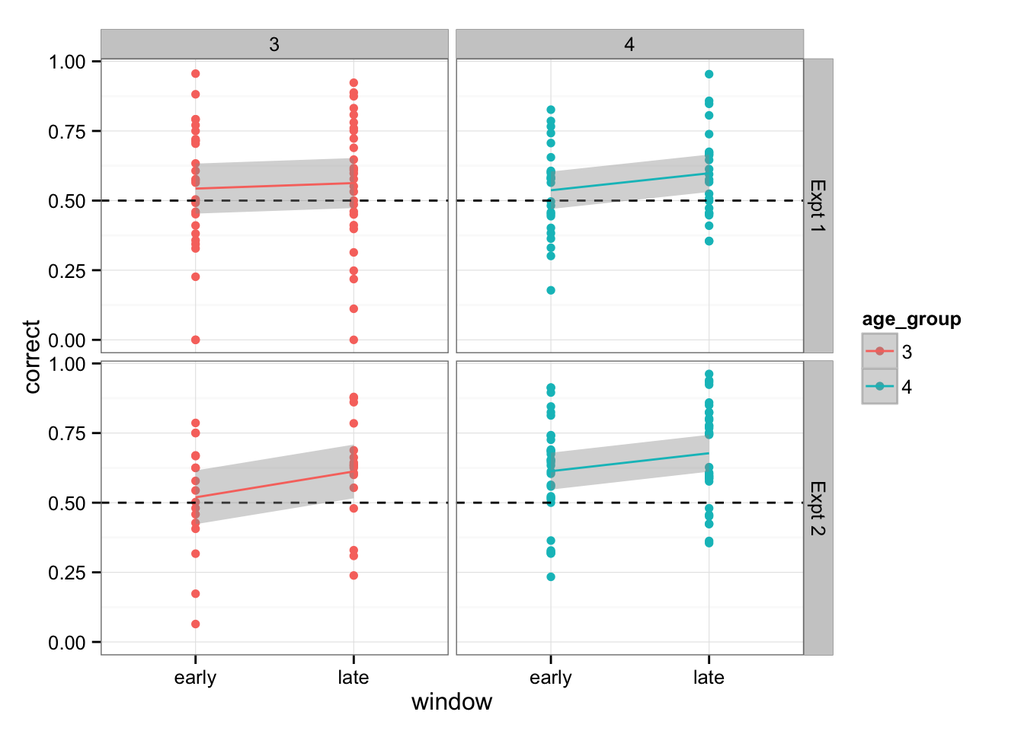

```r
ms <- aggregate(correct ~ expt + age_group + window + subid, mss, mean)
levels(ms$expt) <- c("Expt 1", "Expt 2")
qplot(window, correct, col=age_group, data=ms) +
  facet_grid(expt~age_group) +
  geom_hline(yintercept=.5,lty=2) +
  geom_smooth(method="lm", aes(group=1))
```

### model

```r
simp.lm <- lmer(correct ~ expt * age_group * window
                + (window | subid) + (expt + age_group | item), # more complex random effects fail to converge
                data=mss)
summary(simp.lm)
```

```
## Linear mixed model fit by REML ['lmerMod']
## Formula: correct ~ expt * age_group * window + (window | subid) + (expt +
##     age_group | item)
##    Data: mss
##
## REML criterion at convergence: 483.3
##
## Scaled residuals:
##     Min      1Q  Median      3Q     Max
## -2.0335 -0.6592  0.0692  0.9050  1.5654
##
## Random effects:
##  Groups   Name        Variance Std.Dev. Corr
##  subid    (Intercept) 4.40e-03 0.0663
##           windowlate  2.90e-04 0.0170   1.00
##  item     (Intercept) 5.12e-04 0.0226
##           expt2       4.13e-04 0.0203   -1.00
##           age_group4  2.12e-05 0.0046   -1.00  1.00
##  Residual             1.08e-01 0.3286
## Number of obs: 690, groups:  subid, 100; item, 8
##
## Fixed effects:
##                             Estimate Std. Error t value
## (Intercept)                   0.5523     0.0380   14.52
## expt2                        -0.0129     0.0592   -0.22
## age_group4                   -0.0123     0.0535   -0.23
## windowlate                    0.0267     0.0495    0.54
## expt2:age_group4              0.0840     0.0776    1.08
## expt2:windowlate              0.0654     0.0781    0.84
## age_group4:windowlate         0.0311     0.0715    0.43
## expt2:age_group4:windowlate  -0.0615     0.1032   -0.60
##
## Correlation of Fixed Effects:
##             (Intr) expt2  ag_gr4 wndwlt ex2:_4 expt2: ag_g4:
## expt2       -0.640
## age_group4  -0.686  0.440
## windowlate  -0.624  0.401  0.444
## expt2:g_gr4  0.468 -0.752 -0.689 -0.306
## expt2:wndwl  0.395 -0.628 -0.281 -0.633  0.479
## ag_grp4:wnd  0.432 -0.278 -0.631 -0.692  0.435  0.438
## expt2:g_g4: -0.299  0.475  0.437  0.479 -0.631 -0.756 -0.693
```